# Oklahoma City Travel Analysis

Exploring Accessibility

**Nur Shlapobersky** + **Sage Voorhees**  
SES 5394: Travel Behavior and Forecasting Spring Semester 2023

# Oklahoma City at a Glance

Figure 1: Sketch of Oklahoma City boundaries and interstate highways.

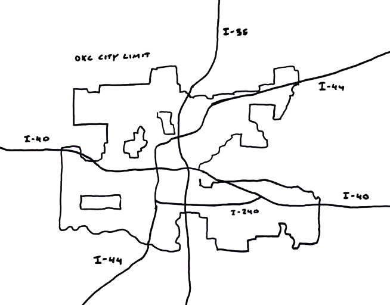

Oklahoma City is the capital of Oklahoma and the largest city in the state. Three major interstates–I-35, I-40, and I-44 all pass through OKC. As of the 2020 Census, the OKC Metro area is majority white, with a population just shy of 1.5 million people.

2020 Census and 2021 American Community Survey

| Race | Percent of Population |
| --- | --- |
| White | 62% |
| African American | 10% |
| Native American | 3% |
| Asian | 3% |
| Multi-racial | 8% |
| Other | 1% |
| – | – |
| Hispanic | 14% |

Some well-known neighborhoods in OKC include

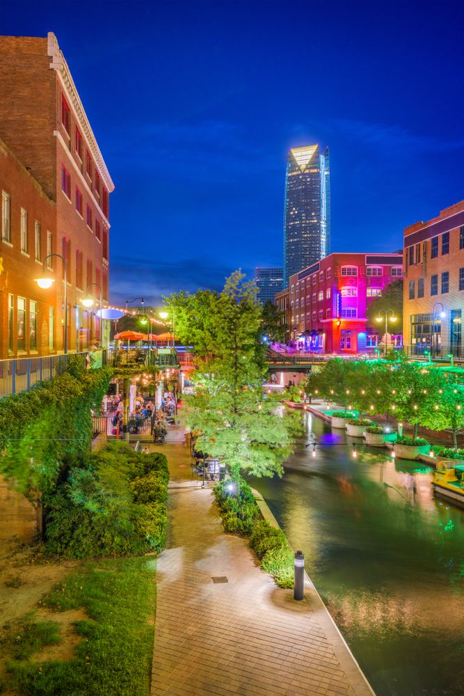

Figure 2: The Bricktown neighborhood.

- Downtown
- Bricktown - an entertainment district
- Deep Deuce - a residential, formerly African American neighborhood
- The Arts District
- Film Row
- Midtown
- Automobile Alley
- Plaza District
- Cottage District
- Uptown
- Asian District
- Paseo Arts District
- Crown-Heights-Edgemere Heights
- Western Avenue Corridor
- 39th Street Enclave

# Elements of the Model

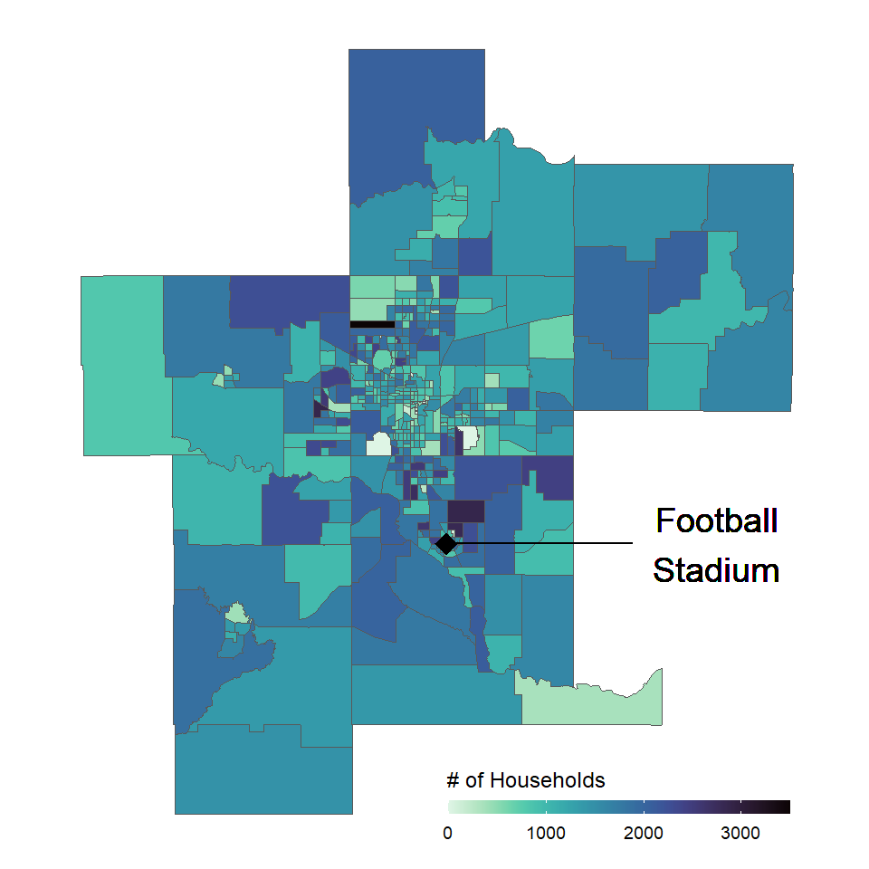

Figure 3: Number of households by census tract

## Road Network

The longest distance between zones by car was just over 3 hours and 15 minutes (190.5 minutes). The shortest distance was half a minute (0.5 minutes). The average distance between TAZ centroids is roughly 30 minutes (30.7), the median time is around 25 minutes (25.6 minutes). Roads highlighted in red in Figure 4 were modeled as two-way rural roads.

Figure 4: The modeled Oklahoma City road network.

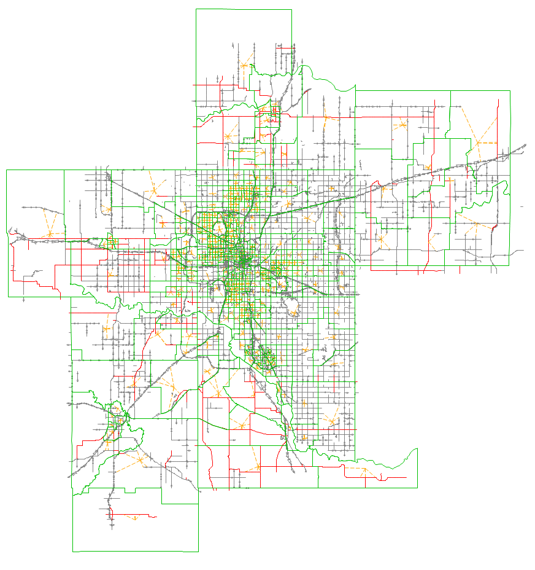

## Public Transit Network

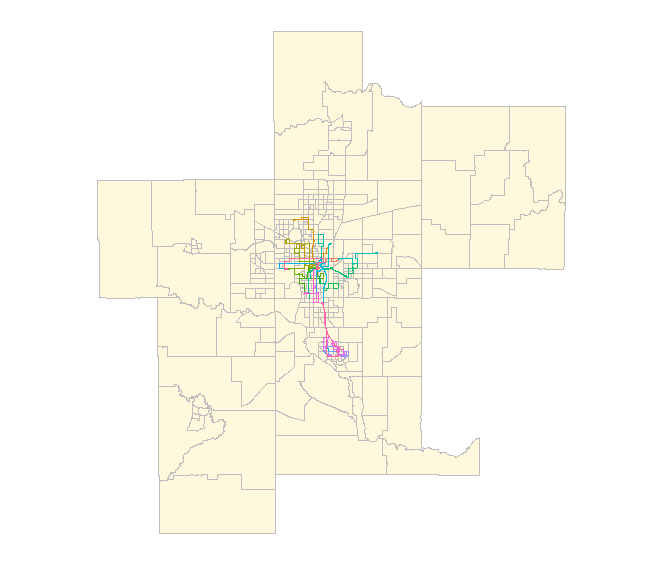

Figure 5: Full county map with public transit.

Figure 6: The public transit network in Oklahoma City.

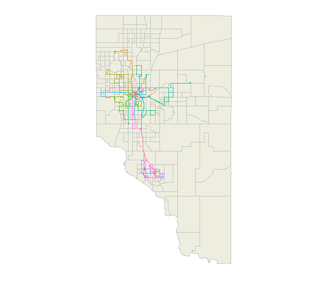

## Travel Times

Using the networks we created, we generated travel time skims which provide travel times between every TAZ. By selecting a subset we can map every zone’s travel time by car to the University of Oklahoma, as in Figure 5.

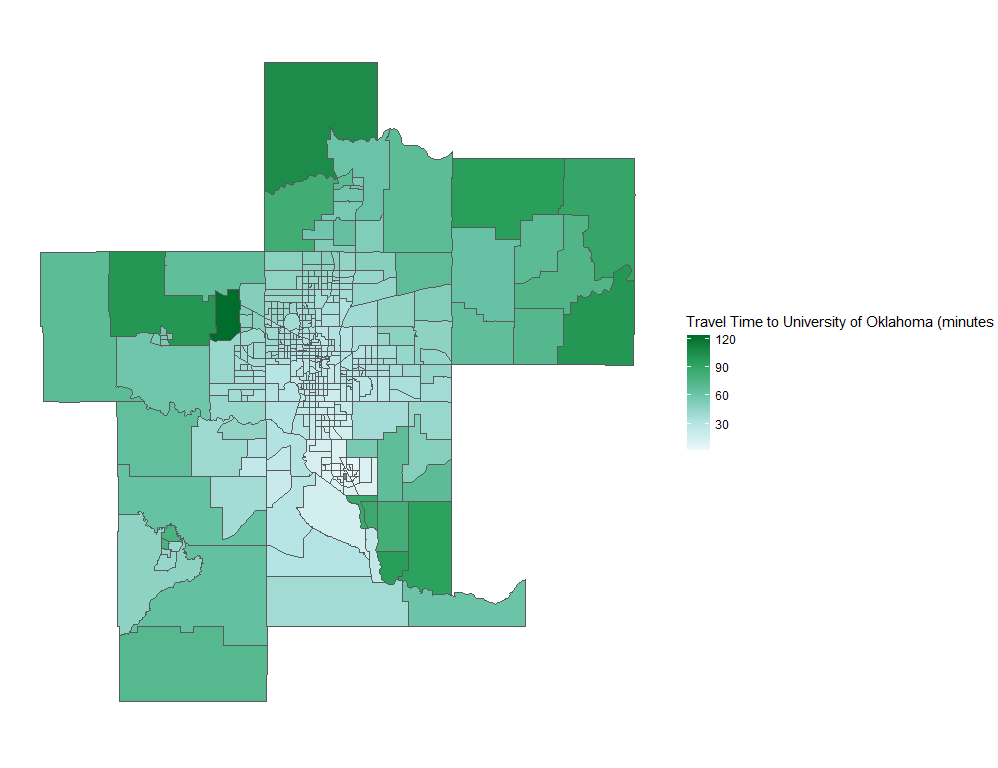

**Fig 5**: Travel Time from UOK to other locations using a car

As well as the travel time by bus from the University to other zones, as in Figure 6 (note that many are grayed out because they cannot be reached by bus).

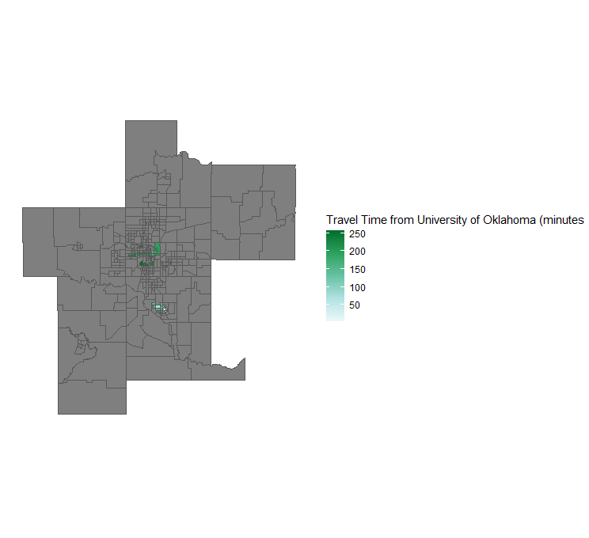

**Fig 6**: Travel Time from UOK to other locations using public transit

# **Accessibility**

**Accessibility** is a measure of how many destination travelers can reach within a *perceived* reasonable time using transportation modes available to them. Put an alternative, and slightly more mathematical way:

Mobility: reasonable reachable area
$$accessibility = mobility * proximity$$

Proximity: opportunities per area

We determine accessibility based on the network skims mentioned earlier and employment data. Travel times are used in a decay function to scale the “worth” of each opportunity, and these are all summed together to determine the accessibility score. See Appendix B for more information.

## Accessibility by Car

Car access is distributed as is typical for a metropolitan area: the downtown, being both dense and centrally located, has higher scores than the outlying areas.

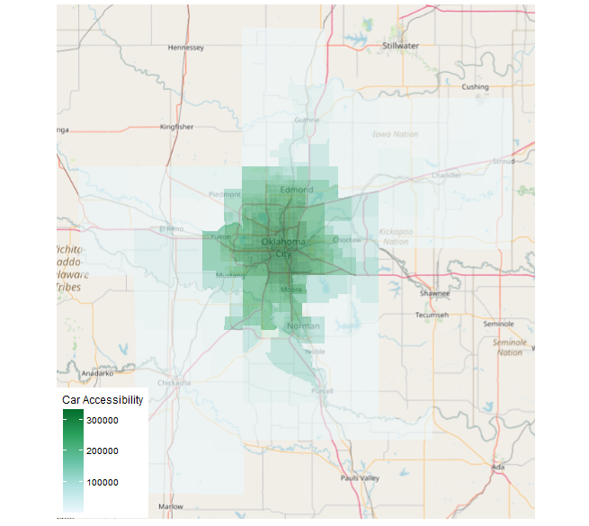

**Fig 7**: Car accessibility scores for each zone

While they don’t necessarily represent a large percent of the land area, there are many of those downtown high-scoring zones because they are smaller, and this is what forms the right peak in the distribution shown in Figure 8. The left peak represents the outlying rural zones.

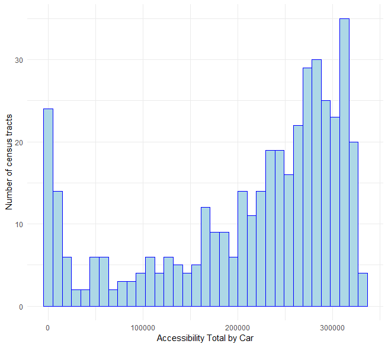

**Fig 8**: Distribution of zone accessibility scores

## Accessibility by Transit

Transit in Oklahoma City is quite limited to the areas in and around Downtown and the University campus. The bus lines between the two areas notably bypass most of the zones in between, creating the two island-like regions in Figure 9.

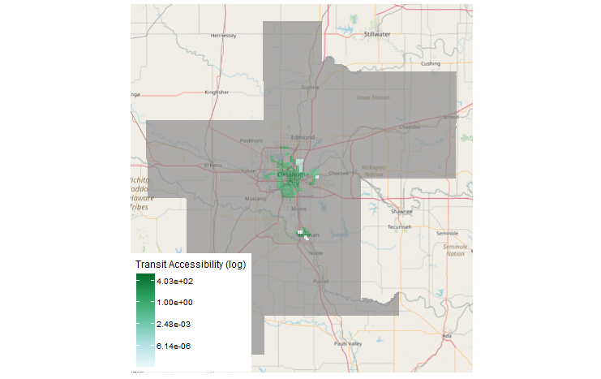

**Fig 9**: Transit accessibility scores for each zone (on a log scale)

Taking a look at the accessibility map without using a log transformation in Figure 10, we can see that the majority of those zones have very similar low scores. There are just a few outliers with much higher accessibility scores due to the proximity of transit hubs where many of the bus lines meet.

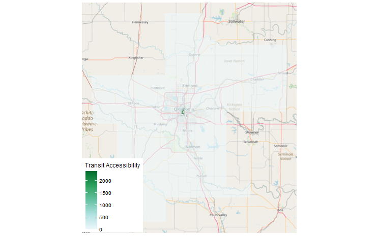

Those outliers can also be seen in Figure 11 at the far right tail of the distribution.

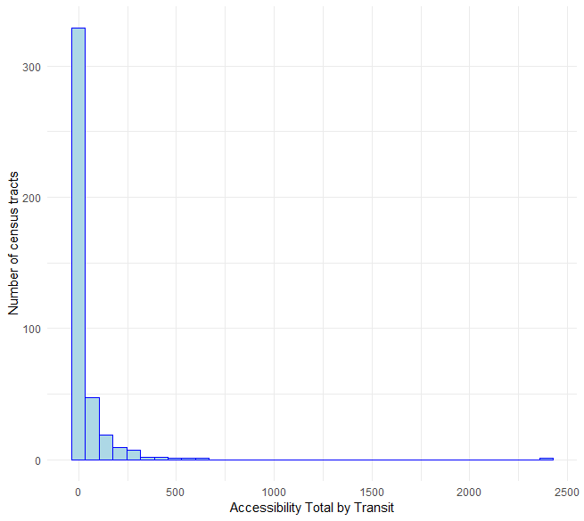

**Fig 11**: Distribution of zone accessibility scores

# **Trip Attractions and Trip Productions**

**Estimating Productions and Attractions** Data for our analysis of Trip Attractions and Productions comes from the National Household Travel Survey (NHTS) from 2017.

To generate Trip Attractions and Trip Productions for each transit analysis zones, we broke up trip types into three main categories.

1. Home Based Work: Travel between work and home
2. Home Based Other: Travel between home and places other than a workplace
3. Non-Home Based: Travel that does not start or end at home

To generate our trip attractions and productions we conducted a linear regression using factors present in both the NHTS and the ACS.

We used:

1. Median Income (Continuous)
2. Whether or not the household had a vehicle (yes, no)
3. Household size (1 person, 2 people, 3 people, 4 or more people)
4. Whether or not the household had kids (yes, no)

We had a very low R-Squared value in our regressions ranging from .124 to .129. In our regressions, only household size and presence of kids was statistically significant, so we only used these variables to generate trip attractions and productions.

#### Totals for Trip Productions and Attractions

**Home Based Work:** 124,464  
**Home Based Other:** 1,392,300  
**Non Home Based:** 1,618,000

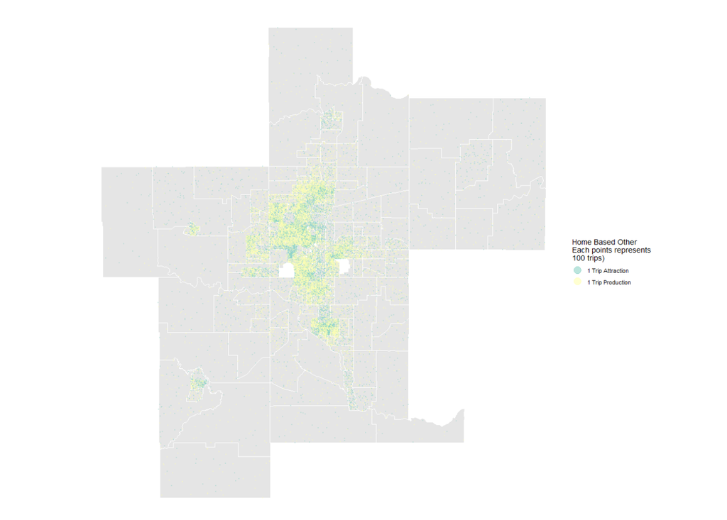

**Fig 12**: Home Based Other, Trip Productions and Attractions

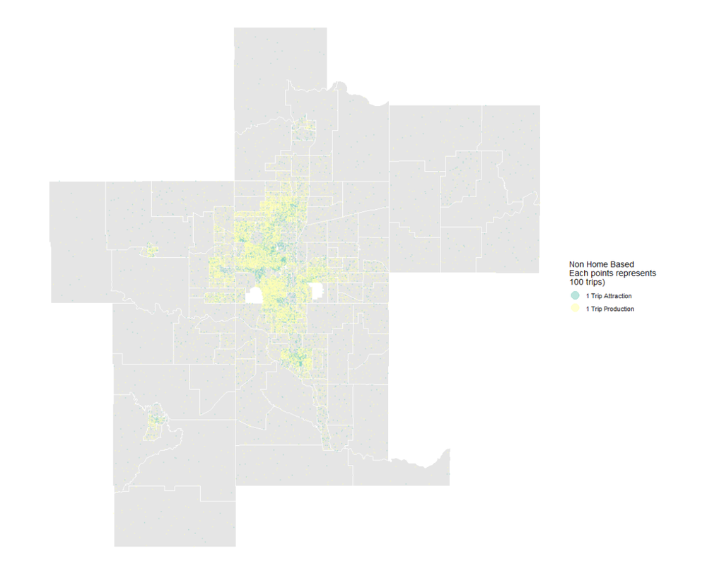

**Fig 13**: Non Home Based, Trip Productions and Attractions

We also used NHTS data to examine mode share in OKC based on various trip types.

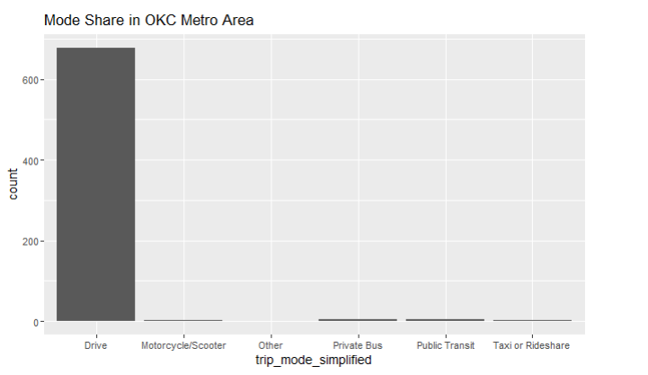

**Fig 14**: Mode Share OKC Metro Area

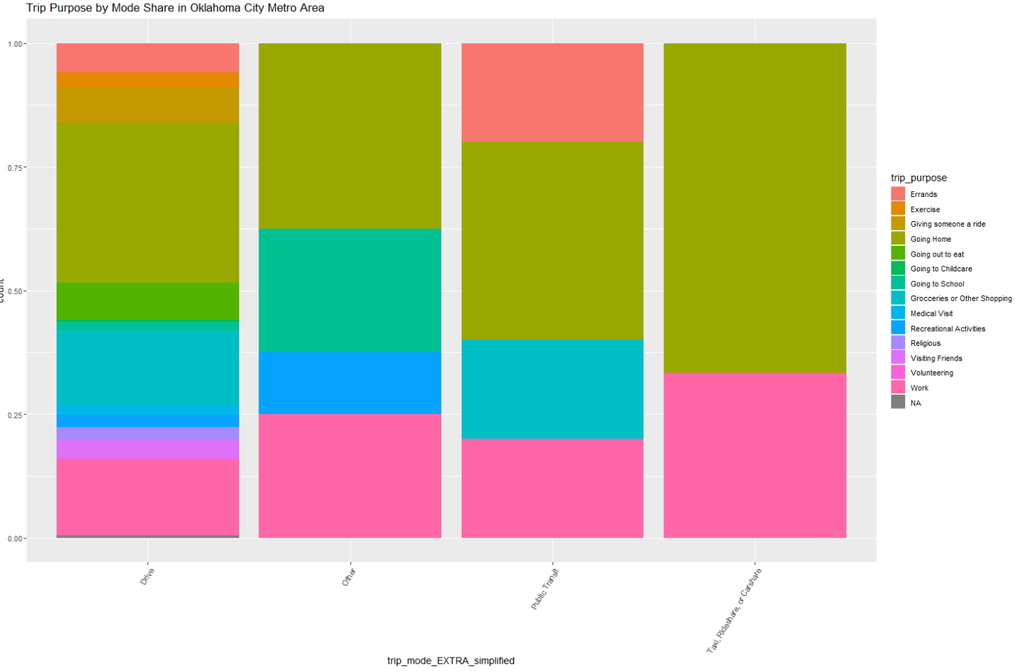

**Fig 15**: Mode Share and Trip Purpose

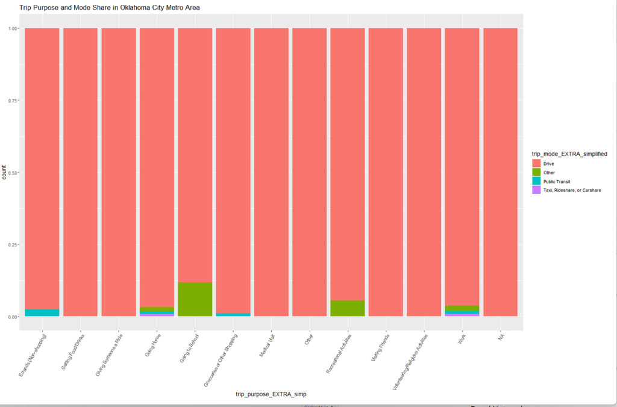

**Fig 16**: Mode Share and Trip Purpose Detail

# Appendix

## A: Methodology and Sources

### Demographics and Land Use Data

For data about the population density, income, household size, and vehicle availability of we used 5-year Sample American Community Survey (ACS) Data from 2021. For information about the land use and employment we used Longitudinal Employer Household Dynamics (LEHD). For geographic boundaries we used census data.

### Road Network

To generate the Road Network we used data pulled from **Open Street Map**, downloaded through the service **https://extract.bbbike.org/.** We included in our road network all road segments labeled as motorways, motorway_links, secondary, tertiary, trunks or unclassified roads. We decided to include the unclassified roads when we realized that major roads including US-77, US-62 were not included in motorways. Adding in unclassified roads also brought back in “boulevards,” such as Oklahoma City Boulevard and North Lincoln Boulevard. Our assumption is that since the original data did not label any roads as “primary,” many roads that would have been considered primary were instead labeled as unclassified.We then began to generate a transit skim using the software **Transcad.**

### *Public Transportation Network*

In this model we used General Transit Feed Specification (GTFS) data pulled from Oklahoma City [EMBARK’s GTFS feed](https://embarkok.com/data/gtfs/google_transit.zip).

## B: Assumptions

### *Transit Network*

1. The maximum initial wait time for a public transit trip was 15 minutes.
2. The walk speed for a traveler is 2.8 miles per hour.
3. Buses move at 30 miles per hour.
4. Centroid connectors could be a maximum of 0.5 miles long.

### *Accessibility Metrics*

1. We are weighting the portion of time spent waiting for a bus or train as 2.5 times the in-vehicle travel time (IVTT)
2. We are using a logistic decay function with an inflection point of 25 and standard deviation of 5

## C: Supplemental Visualizations

### *Census and Employment Data*

Figure 7: Employment is concentrated in the downtown area. Employment information is not available for many of our Transit Analysis Zones

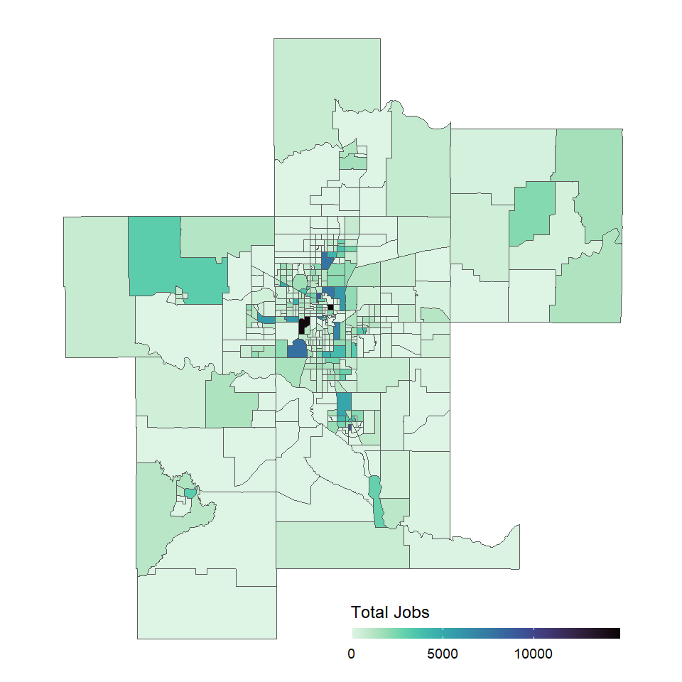

Figure 8: Majority of employment in OKC metro area is in the service industry.

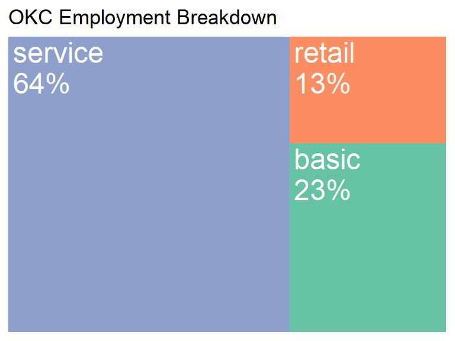

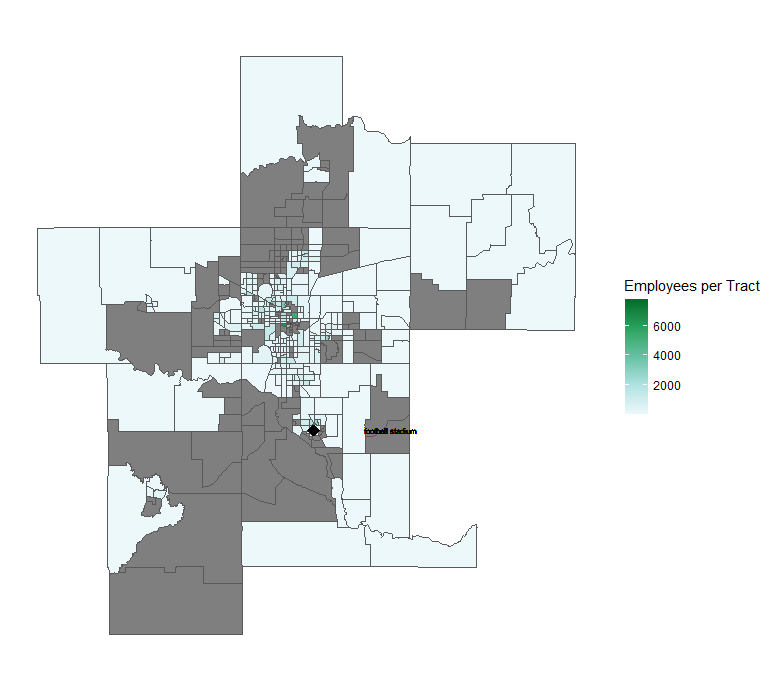

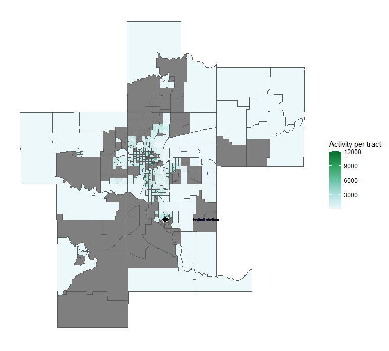

**Fig A3**: Employment + Activity Density is greatest in downtown OKC

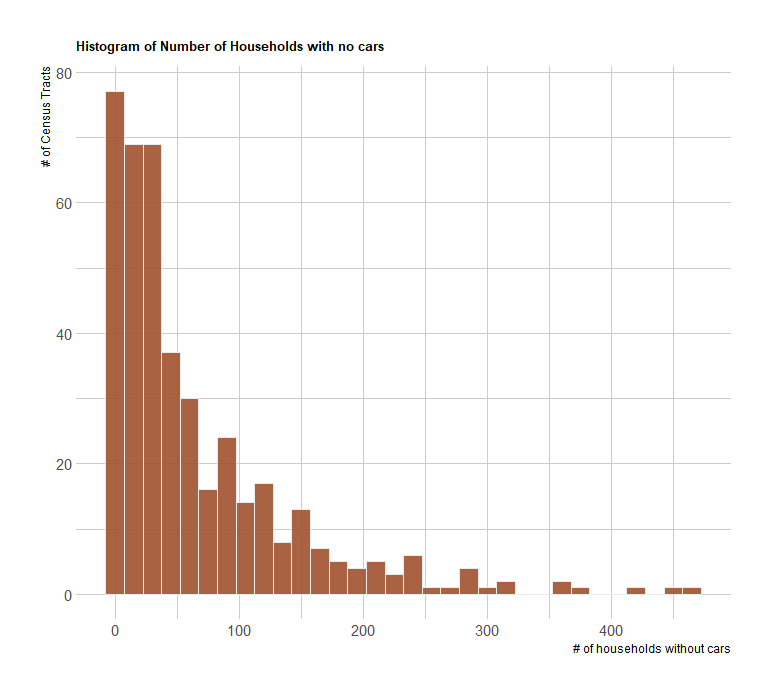

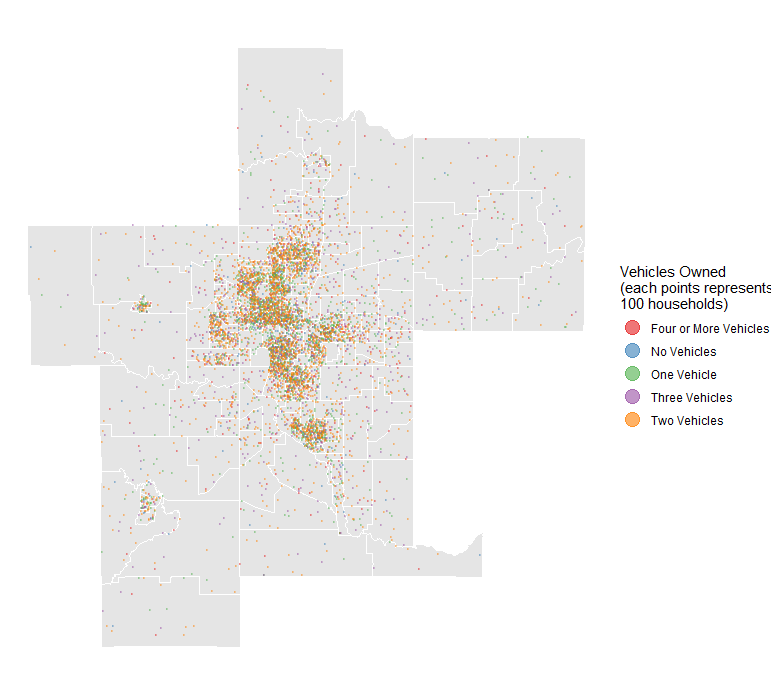

**Fig A5**: Vehicle Ownership Dot Density Map

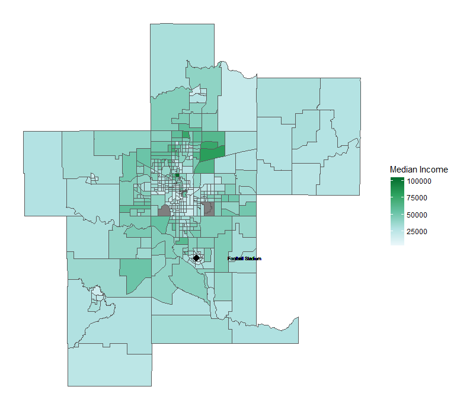

**Fig A6**:Highest income neighborhoods are north of downtown

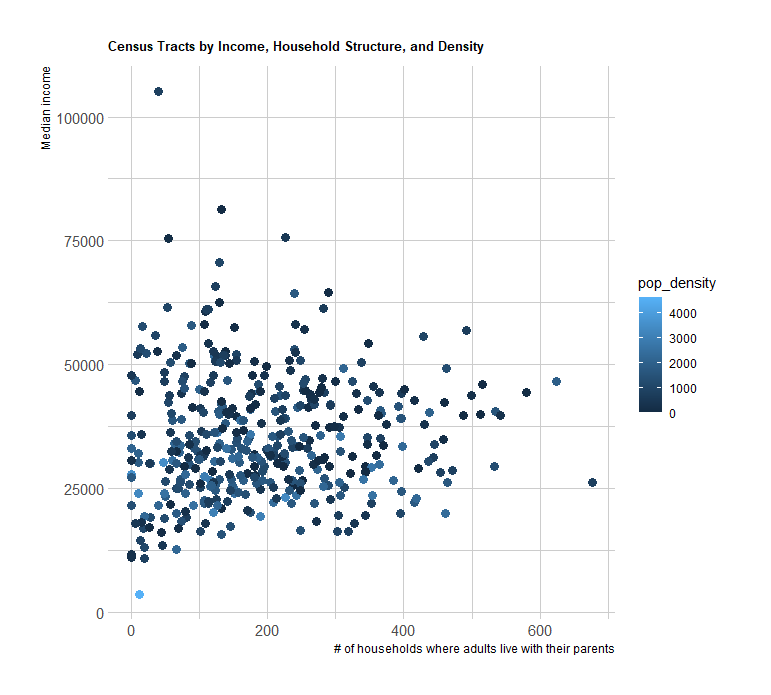

**Fig A7**: Income, Population Density, and Adults Living with their Parents